# BMEmapping: An R Package for Spatial Interpolation using Bayesian Maximum Entropy

### 3.4 BME prediction

Based on the estimated posterior density (25), the posterior point estimates and uncertainty metrics defined in (21), (20), (23), (22) and (24) are computed numerically over a discrete grid $\{z_{k,j}\}_{j=1}^{n_k}$ with constant step size $\Delta z_k$ as:

$$\hat{z}_{k \mid \mathcal{K}} = \arg\max_{z_{k,j}} \, f_{\mathcal{K}}(z_{k,j})
\tag{28},$$

$$\bar{z}_{k \mid \mathcal{K}} = \sum_{j=1}^{n_k} z_{k,j} \, f_{\mathcal{K}}(z_{k,j}) \, \Delta z_k
\tag{29},$$

$$m_{k \mid \mathcal{K}} = \left\{ z_{k,m} \ \middle| \ \sum_{j=1}^{m} f_{\mathcal{K}}(z_{k,j}) \, \Delta z_k \approx 0.5 \right\}
\tag{30},$$

$$\sigma^2_{k \mid \mathcal{K}} = \sum_{j=1}^{n_k} \left( z_{k,j} - \bar{z}_{k \mid \mathcal{K}} \right)^2 f_{\mathcal{K}}(z_{k,j}) \, \Delta z_k
\tag{31},$$

$$\left[L_{k \mid \mathcal{K}} , U_{k \mid \mathcal{K}}\right]_{\alpha} =
\left[
\left\{\sum_{j=1}^{l} f_{\mathcal{K}}(z_{k,j}) \, \Delta z_k \approx \frac{\alpha}{2} \right\} ,
\left\{\sum_{j=1}^{u} f_{\mathcal{K}}(z_{k,j}) \, \Delta z_k \approx 1 - \frac{\alpha}{2} \right\}
\right]\tag{32},$$

where $\Delta z_k = z_{k, j+1} - z_{k, j}$ represents the uniform discretization interval used in the numerical integration over the support `zk_range`.

The `bme_predict` and `q_bme_predict` functions use the above discrete numerical formulations to evaluate localized point and uncertainty estimations across individual or multiple target locations for the Conventional BME and Quantile-Based BME frameworks, respectively. Both functions accept coordinate inputs `x` as either a single two-dimensional numeric coordinate vector or a multi-row, two-column spatial matrix for batch processing.

A key distinction between the two interfaces resides in their hyperparameter configuration profiles: while the conventional engine (`bme_predict`) requires manual specification of spatial structures (`model`, `nugget`, `sill`, `range`), the quantile pipeline (`q_bme_predict`) automates structural spatial continuity by resolving spatial dependencies natively over an internal quantile ensemble.

To specify the desired output metrics, users can pass a string vector to the `type` argument, which accepts combinations of `"mean"`, `"mode"` and `"median"`.

The sample syntaxes to call the respective interpolation pipelines are:

```r
# CBME Prediction
bme_predict(x, data_object, model, nugget, sill, range,
            nsmax, nhmax, n, zk_range, type)

# QBME Prediction
q_bme_predict(x, data_object, nsmax, nhmax, n,
              zk_range, nq, type)
```

The sample syntaxes to calculate the respective BME credible intervals are presented below, where the `level` parameter defines the targeted probability mass for uncertainty quantification. For instance, setting `level = 0.90` computes a symmetric $90\%$ spatial credible interval directly from the localized non-Gaussian posterior distribution.

```r
# CBME interval
bme_predict_ci(x, data_object, model, nugget, sill, range,
               nsmax, nhmax, n, zk_range, level)

# QBME interval
q_bme_predict_ci(x, data_object, nsmax, nhmax, n,
                 zk_range, nq, level)
```

### 3.5 Model assessment

To rigorously evaluate the predictive performance and structural integrity of both interpolation frameworks, the package provides dedicated cross-validation (CV) engines: `bme_cv()` for CBME and `q_bme_cv()` for QBME. These functions execute diagnostic validation routines exclusively at hard data locations, as the true values at soft locations are unobserved and cannot serve as direct baselines for accuracy. Both functions support flexible K-fold data partitioning alongside exact Leave-One-Out Cross-Validation (LOOCV), which is triggered automatically by setting the fold parameter `k` equal to the total number of hard observations.

Beyond assessing model bias and precision, these CV routines serve as an essential diagnostic tool for optimizing and tuning theoretical variogram parameters. Depending on the user-specified `type` argument, spatial predictions are generated using either the localized posterior mean or mode.

The output of both functions is structured as a `list` containing two primary components:

1. **A detailed prediction** `data.frame`: Comprising spatial coordinates (`ch`), true observations ($\boldsymbol{z}_h$), predicted estimates ($\boldsymbol{z}^\ast_h$), predictive variances (computed exclusively when `type = "mean"`), prediction residuals, and the cross-validation fold indices. It also contains the prediction residuals, defined as $\boldsymbol{e}_h = \boldsymbol{z}_h - \boldsymbol{z}^\ast_h$.
2. **A summary metrics array**: A quantitative assessment summarizing overall model performance across four key statistical dimensions: mean error (ME), mean absolute error (MAE), root mean squared error (RMSE), and the coefficient of determination ($R^{\scriptsize 2}$). These diagnostics are computed explicitly at the hard data locations as follows:

$$\mathrm{ME} = \dfrac{1}{n_h} \sum^{n_h}_{i} e_{h,i} , \\
\mathrm{MAE} = \dfrac{1}{n_h} \sum^{n_h}_{i} {|e_{h,i}|}, \\
\mathrm{RMSE} = \sqrt{\dfrac{1}{n_h} \sum^{n_h}_{i} e^2_{h,i}}, \\
\mathrm{R}^2 = 1 - \dfrac{\sum^{n_h}_{i}(e_{h,i}^2)}{\sum^{n_h}_{i}(z_{h,i} - \bar{\boldsymbol{z}}_{h})^2}$$

where $n_h$ is the number of hard data locations and $\bar{\boldsymbol{z}}_{h} = \dfrac{1}{n_h}\sum^{n_h}_{i}z_{h,i}$. Below is an example syntax for calling these functions for CBME and QBME respectively:

```r
# CBME
bme_cv(data_object, model, nugget, sill, range,
       nsmax, nhmax, n, zk_range, type, k)

# QBME
q_bme_cv(data_object, nsmax, nhmax, n, zk_range, nq, type, k)
```

To facilitate user-friendly data exploration and interpretation, we provide two custom S3 methods: `summary.BMEmapping` and `plot.BMEmapping`. The `summary.BMEmapping` method generates a concise textual summary of the performance metrics: ME, MAE, RMSE and R$^{\scriptsize 2}$ associated with the prediction process. The `plot.BMEmapping` method offers a visual representation of the data, differentiating hard and soft data types using distinct shapes and colors, and includes prediction and diagnostic plots for evaluating model performance. Together, these methods support an intuitive and streamlined workflow for both summarizing and visualizing spatial data within the BME framework.

An overview of the core functions available in the BMEmapping package is presented below. These functions constitute the foundation of the package’s functionality for organizing input data, modeling spatial uncertainty, and generating predictions within the BME framework:

*Data pipeline configuration*

- **`bme_map`** Constructs a unified data object encapsulating coordinate structures, spatial attributes, hard measurements, and soft-interval constraints to condition the interpolation space.

*Posterior density estimation*

- **`prob_zk`** Computes posterior densities using the CBME approach.
- **`q_prob_zk`** Computes posterior densities using the QBME approach.

*Probabilistic spatial prediction and uncertainty estimation*

- **`bme_predict`** Computes spatial point estimates using the CBME approach.
- **`q_bme_predict`** Computes spatial point estimates using the QBME approach.
- **`bme_predict_ci`** Constructs credible intervals using the CBME approach.
- **`q_bme_predict_ci`** Constructs credible intervals using the QBME approach.

*Model validation and S3 graphics*

- **`bme_cv`** Executes K-fold or exact Leave-One-Out Cross-Validation (LOOCV) at hard data locations using the CBME approach.
- **`q_bme_cv`** Executes K-fold or exact LOOCV at hard data locations using the QBME approach.
- **`summary()`** Provides standard geostatistical error metrics for BMEmapping objects.
- **`plot()`** Provides graphical visualizations (spatial, prediction and residual plots) of BMEmapping objects.

## 4 Illustrations

### 4.1 Example 1: Using the QBME implementation

#### Data

```r
data("utsnowload", package = "BMEmapping")
head(utsnowload)
```

```
  latitude longitude        hard lower upper
1    40.44   -112.24  0.09696012    NA    NA
2    39.94   -112.41  0.12258678    NA    NA
3    37.51   -113.40 -0.02302358    NA    NA
4    37.49   -113.85  0.50354362    NA    NA
5    39.31   -109.53 -0.68611327    NA    NA
6    40.72   -109.54 -0.53000397    NA    NA
```

```r
tail(utsnowload)
```

```
    latitude longitude hard      lower     upper
227  39.9286 -111.0764   NA -0.7047409 0.8157156
228  40.3000 -111.2550   NA -0.5029085 0.5864070
229  40.4447 -111.7075   NA -0.6477729 0.8168399
230  40.7908 -111.4078   NA -1.2416545 0.4243417
231  37.7064 -112.1456   NA -1.1131694 0.2396519
232  40.9139 -111.3983   NA -1.4869460 0.3564833
```

```r
# hard data locations
ch <- utsnowload[1:67, c("latitude", "longitude")]

# hard data values
zh <- utsnowload[1:67, c("hard")]

# soft data locations
cs <- utsnowload[68:227, c("latitude", "longitude")]

# lower and upper bounds of soft data (intervals)
a <- utsnowload[68:227, c("lower")]
b <- utsnowload[68:227, c("upper")]
```

The selected data are then organized into a `BMEmapping` object as shown below.

```r
data_object <- bme_map(ch, cs, zh, a, b)
```

Figure 2 presents a spatial visualization of the dataset, illustrating the geographic distribution of both hard and soft data types. The plot not only marks the locations where data were collected, but also differentiates between the two data types. In addition, it conveys the level of uncertainty associated with the soft data by displaying the corresponding interval widths, allowing for an intuitive understanding of the spatial variability and data reliability across the study area.

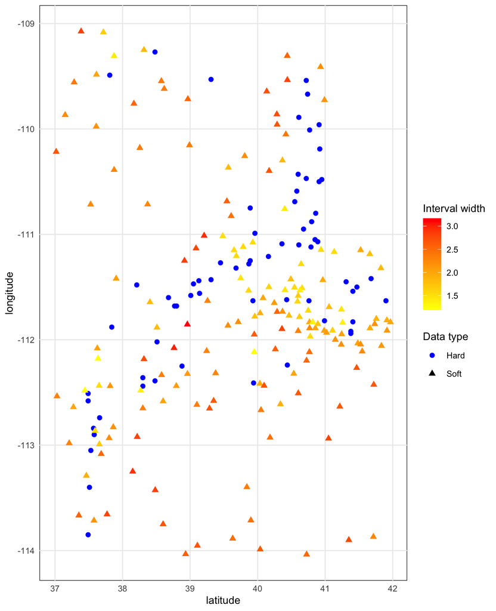

Figure 2: A spatial plot of data.

```r
plot(data_object)
```

#### BME prediction

```r
# estimation locations
xk <- utsnowload[228:232, c("latitude", "longitude")]
xk
```

```
    latitude longitude
228  40.3000 -111.2550
229  40.4447 -111.7075
230  40.7908 -111.4078
231  37.7064 -112.1456
232  40.9139 -111.3983
```

Next, we examine the posterior distribution estimation at a few individual locations. This step is not essential and can be skipped without interrupting the prediction process. However, it is strongly recommended that users go through this step to learn the patterns of the posterior distribution as well as adjust its domain `zk_range`. In the following demonstration, we begin with the default values for all the optional arguments `nsmax`, `nhmax`, `zk_range`, `n` and `nq`. A numerical evaluation and graphical visualization of the posterior predictive densities at the first four prediction locations is performed using the `q_prob_zk` function, as illustrated in Figure 3.

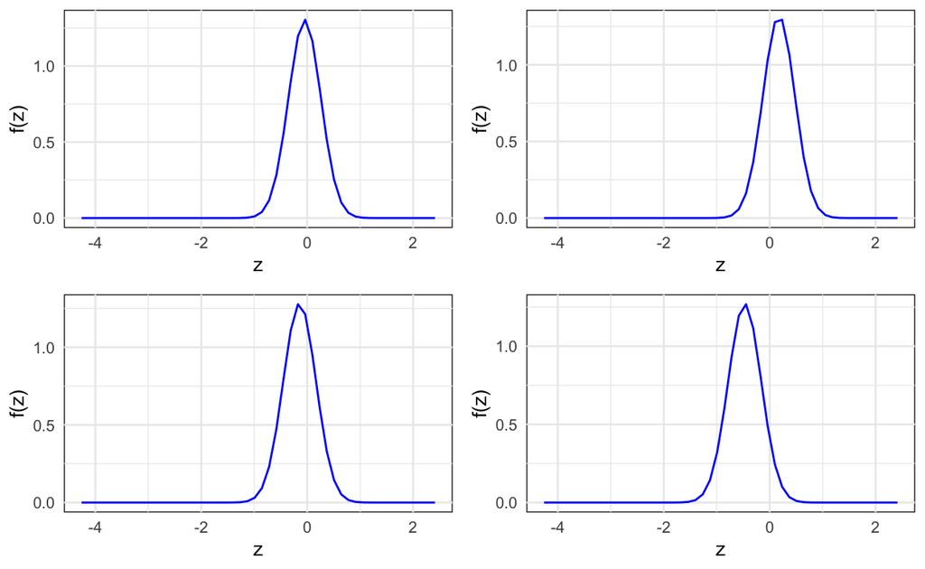

Figure 3: Posterior density plots at selected sites using the default range of zk.

```r
p_1 <- q_prob_zk(xk[1,], data_object)
p_2 <- q_prob_zk(xk[2,], data_object)
p_3 <- q_prob_zk(xk[3,], data_object)
p_4 <- q_prob_zk(xk[4,], data_object)
p_df <- cbind.data.frame(p_1, p_2[, 2], p_3[, 2], p_4[, 2])
names(p_df) <- c("zk_i", "p1", "p2", "p3", "p4")

# Function to generate ggplot for a given column name
plot_prob_curve <- function(df, pi_col) {
  ggplot(df, aes_string(x = "zk_i", y = pi_col)) +
    geom_line(color = "blue", linewidth = 0.5) +
    labs(x = "z", y = "f(z)") +
    theme_minimal(base_size = 10) +
    theme(
      panel.background = ggplot2::element_rect(fill = "white",color = "black")
    )
}

# Generate individual plots
p1 <- plot_prob_curve(p_df, "p1")
p2 <- plot_prob_curve(p_df, "p2")
p3 <- plot_prob_curve(p_df, "p3")
p4 <- plot_prob_curve(p_df, "p4")

# Arrange in a 2x2 grid
grid.arrange(p1, p2, p3, p4, ncol = 2)
```

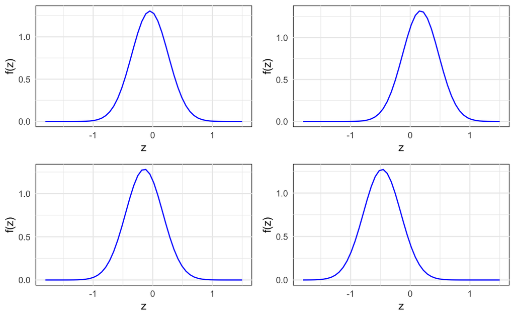

Figure 4: Posterior density plots at selected sites using the updated range of zk.

```r
q_1 <- q_prob_zk(xk[1,], data_object, zk_range = c(-1.8, 1.5))
q_2 <- q_prob_zk(xk[2,], data_object, zk_range = c(-1.8, 1.5))
q_3 <- q_prob_zk(xk[3,], data_object, zk_range = c(-1.8, 1.5))
q_4 <- q_prob_zk(xk[4,], data_object, zk_range = c(-1.8, 1.5))
q_df <- cbind.data.frame(q_1, q_2[, 2], q_3[, 2], q_4[, 2])
names(q_df) <- c("zk_i", "q1", "q2", "q3", "q4")

# Generate individual plots
q1 <- plot_prob_curve(q_df, "q1")
q2 <- plot_prob_curve(q_df, "q2")
q3 <- plot_prob_curve(q_df, "q3")
q4 <- plot_prob_curve(q_df, "q4")

grid.arrange(q1, q2, q3, q4, ncol = 2)
```

```r
# posterior mode predictions
q_bme_predict(xk, data_object, zk_range = c(-1.8, 1.5), type = "mode")
```

```
    latitude longitude    mode
228  40.3000 -111.2550 -0.0490
229  40.4447 -111.7075  0.1531
230  40.7908 -111.4078 -0.1163
231  37.7064 -112.1456 -0.4531
232  40.9139 -111.3983 -0.0490
```

```r
# posterior mean predictions
q_bme_predict(xk, data_object, zk_range = c(-1.8, 1.5), type = "mean")
```

```
    latitude longitude    mean variance
228  40.3000 -111.2550 -0.0468   0.0934
229  40.4447 -111.7075  0.1738   0.0913
230  40.7908 -111.4078 -0.1425   0.0965
231  37.7064 -112.1456 -0.4716   0.0982
232  40.9139 -111.3983 -0.0611   0.0949
```

```r
# posterior median predictions
q_bme_predict(xk, data_object, zk_range = c(-1.8, 1.5), type = "median")
```

```
    latitude longitude  median
228  40.3000 -111.2550 -0.0806
229  40.4447 -111.7075  0.1402
230  40.7908 -111.4078 -0.1761
231  37.7064 -112.1456 -0.5052
232  40.9139 -111.3983 -0.0945
```

A 90% and 95% credible intervals can be computed as

```r
# 90% credible interval
q_bme_predict_ci(xk, data_object, zk_range = c(-1.8, 1.5), level = 0.90)
```

```
    latitude longitude Lower_90 Upper_90
228  40.3000 -111.2550  -0.5830   0.4215
229  40.4447 -111.7075  -0.3591   0.6378
230  40.7908 -111.4078  -0.6894   0.3363
231  37.7064 -112.1456  -1.0227   0.0106
232  40.9139 -111.3983  -0.6029   0.4123
```

```r
# 95% credible interval
q_bme_predict_ci(xk, data_object, zk_range = c(-1.8, 1.5), level = 0.95)
```

```
    latitude longitude Lower_95 Upper_95
228  40.3000 -111.2550  -0.6816   0.5211
229  40.4447 -111.7075  -0.4516   0.7343
230  40.7908 -111.4078  -0.7851   0.4333
231  37.7064 -112.1456  -1.1197   0.1111
232  40.9139 -111.3983  -0.7012   0.5102
```

Finally, we evaluate the predictive accuracy of the BME interpolation (as the posterior mode) by performing a 5-fold CV at hard data locations using the `q_bme_cv` function (for display purposes, only a subset of the results is shown):

```r
QBME_cv <- q_bme_cv(data_object, zk_range = c(-1.8, 1.5), type = "mode", k = 5)
head(QBME_cv, 10)
```

```
   latitude longitude    observed    mode residual fold
1     40.44   -112.24  0.09696012  0.1531  -0.0561    1
2     39.94   -112.41  0.12258678 -0.2510   0.3736    1
3     37.51   -113.40 -0.02302358 -0.1163   0.0933    4
4     37.49   -113.85  0.50354362 -0.2510   0.7545    3
5     39.31   -109.53 -0.68611327 -0.7224   0.0363    2
6     40.72   -109.54 -0.53000397 -1.0592   0.5292    5
7     40.61   -109.89 -0.71923519 -1.0592   0.3400    4
8     40.91   -109.96 -1.31503404 -0.9918  -0.3232    3
9     40.74   -109.67 -0.94879597 -0.9245  -0.0243    2
10    40.92   -110.19 -1.39798035 -1.1939  -0.2041    2
```

To evaluate the predictive performance of the BME interpolation process, a comprehensive summary of key performance metrics can be generated using the following command. This provides insight into the accuracy and reliability of the model’s predictions across the validation dataset:

```r
summary(QBME_cv)
```

```
Summary of BME Cross-Validation
   for hard data locations
--------------------------------
Number of predictions: 67

ME           0.0360
MAE          0.2361
RMSE         0.2995
Rsquared     0.7247
```

The diagnostic plots of the residuals in 5 can be generated using the following command. The plots include *observed versus predicted values*, *residuals versus predicted values*, *Normal Q-Q plot* and *histogram of residuals*, providing insight into the adequacy of model fit.

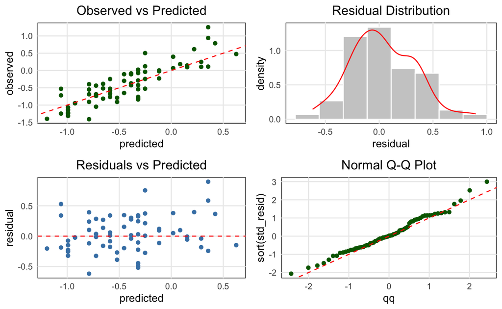

Figure 5: Residual diagnostics for hard data.

```r
plot(QBME_cv)
```

These diagnostic plots provide visual insight into the distribution and statistical properties of residuals from the spatial model and allow assessment of several key modeling assumptions. The *observed-versus-predicted values* plot provides an overall assessment of model fit; predictions that closely follow the observed values indicate that the model captures the main variation in the response. The *residuals-versus-predicted values* plot is particularly useful for assessing homoscedasticity and systematic model misspecification: a roughly constant spread of residuals across the range of predicted values, without a systematic trend or curvature, provides evidence of approximately constant residual variance. The *Normal Q–Q* plot and *histogram of residuals* provide complementary assessments of the assumed residual distribution. Approximate alignment with the reference line in the Q–Q plot, together with a roughly symmetric and unimodal histogram, indicates that the residuals are reasonably consistent with the assumed distribution.

Although these diagnostics provide evidence regarding model fit, residual variance, and the distribution of residuals, they do not by themselves directly establish spatial independence or stationarity. These spatial assumptions require diagnostics that explicitly account for the spatial arrangement of observations. Identifying these features can guide model refinement and improve the reliability of spatial predictions and uncertainty estimates. Users are encouraged to consult (Wackernagel 2003; Banerjee et al. 2014) for further discussion of these key spatial modeling assumptions and guidance on their assessment and interpretation.

### 4.2 Example 2: Using the CBME implementation

#### Simulation Study: Data Generation

The precise true values at the designated soft data locations are subsequently transformed into realistic interval-type uncertainties using a stochastic window generation pipeline. For each soft location, an individual interval width $l_i$ is sampled from a uniform distribution bound by $\left[l_{\text{val}} - 0.5, l_{\text{val}} + 0.5\right]$ with a baseline width of $l_{\text{val}} = 3$, establishing the global scale of measurement uncertainty. To introduce realistic directional bias and asymmetry relative to the true latent value $z_{s,i}$, a relative placement positioning factor $u_i$ is randomly drawn from a restricted uniform range of $\left[0.25, 0.75\right]$. The lower truncation boundary $a_i$ and upper truncation boundary $b_i$ are then mathematically constructed as $a_i = z_{s,i} - l_i u_i$ and $b_i = z_{s,i} + l_i(1 - u_i)$, respectively. This parameterization constructs a heterogeneous set of soft intervals $\left[a_i, b_i\right]$ that strictly enclose the true physical values while masking their exact locations, successfully replicating the vague or clipped data boundaries frequently encountered in operational geostatistics. The data were generated using the following code:

```r
# 1. Setup Simulation Space and Geostatistical Background
set.seed(123)
n <- 625

# Generate static spatial coordinates uniformly across the domain
coords <- data.frame(
  x = runif(n, 0, 100),
  y = runif(n, 0, 100)
)
grid_sf <- st_as_sf(coords, coords = c("x", "y"))

# Define background exponential variogram structure
vgm_model <- vgm(psill = 1.5, model = "Exp", range = 40, nugget = 0.5)

g.dummy <- gstat(
  formula = z ~ 1,
  dummy = TRUE,
  beta = 0,
  model = vgm_model,
  nmax = 40
)

sim <- predict(g.dummy, newdata = grid_sf, nsim = 1)
```

```
[using unconditional Gaussian simulation]
```

```r
# Define explicit mutually exclusive partitioning limits
nh <- 1:125    # Hard data indices
ns <- 126:525  # Soft data indices
nk <- 526:625  # Validation tracking indices

# 2. Main Simulation Configuration (Single Realization Run)
l_val <- 3
q_val <- c(0.25, 0.75)

# Extract true continuous field values for realization j
z_t    <- sim[[paste0("sim", 1)]]
t_data <- cbind(coords, z = z_t)

# Split spatial subsets cleanly without inline semi-colons
ch <- t_data[nh, c("x", "y")]; zh <- t_data[nh, "z"]
cs <- t_data[ns, c("x", "y")]; zs <- t_data[ns, "z"]
ck <- t_data[nk, c("x", "y")]; zk <- t_data[nk, "z"]

# 4. Generate Realistic Soft-Interval Bounding Windows
n_soft <- length(zs)

# Step A: Determine total window length of individual intervals
ln <- runif(n_soft, min = l_val - 0.5, max = l_val + 0.5)

# Step B: Pick random relative positioning factors to introduce skewness
u <- runif(n_soft, min = q_val[1], max = q_val[2])

# Step C: Mathematically calculate lower (a) and upper (b) boundary envelopes
a <- zs - ln * u
b <- zs + ln * (1 - u)
```

The spatial visualization of the simulated data is shown in Figure 6.

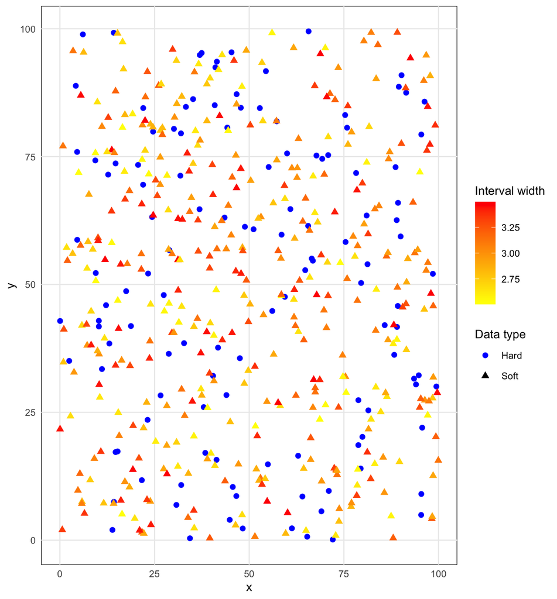

Figure 6: A spatial plot of the simulated data.

```r
data_object <- bme_map(ch, cs, zh, a, b)
plot(data_object)
```